# Linear Mixed Effect Models

Nick Freeland, Bernice Green, Gary Marmon

2022-11-29

## Presentation

Link to slides

## Introduction

Linear Mixed-Effects Models can be used to model correlated data (Gałecki and Burzykowski 2013) that often take the form of cross sectional data or longitudinal data. Cross sectional data feature individuals (level 1) nested in a geographical or social context (level 2), while longitudinal data feature individuals (level 2) measures over several occasions (level 1).(Bell, Fairbrother, and Jones 2019) Data can be nested in more than two levels based on the design of the study.

In the classical approach, all observations are assumed to be independent and identically distributed, but this assumption a=can lead to false results for clustered data. Observations between clustes are assumed independent but observations betweeen cluster are dependent as they belong to the same sub population.Mixed Effects Models can be seen as a combination of ANOVA, a fixed effects model, and VARCOMP, a random effects model.(Demidenko 2013)

Until more recently the only way to handle the type of data mixed-effects model does was through repeated measures ANOVAs. Mixed-effects models are much more versatile in handling variability within and across groups and can handle missing data, providing much better results than the ANOVAs. (Brown 2021)

Brown (2021) gives a theoretical practical account of implementing mixed-effects models and their commonalities and differences with ANOVA, showing ANOVA cannot simultaneously take multiple sources of variation into account when observations are nested across participants, which lowers the ability to detect an effect. Mixed-effects modeling allows a researcher to examine the condition of interest while also considering variability within and across participants and items simultaneously and is a reasonable choice when ANOVA and multiple regression are not.(Brown 2021)

Linear mixed-models are most effective for clustered data with a hierarchical structure or repeated measures. They are also well-suited for time-series data, biological/medical data, and modeling shapes/images. (Demidenko 2013)

The main application for mixed-effect models is in psychology due to the nature of their data and repeated observations across trial participants. However, the applications can extend into almost any field where the variability across a group/person is desired in the analysis. One such example is the use of mixed-effects models on published health data sets to explore the link between smoking and depression in which it was found “Smoking status is robustly associated with depression (or depressive symptomatology) at 1 ½ to 2 times the risk of nonsmoking across a variety of study designs, depression measurements, and participant populations” (Luger, Suls, and Vander Weg 2014).

The critical slope of mixed-effects models is also often discussed in literature, finding failure to include the critical slope in the test of an interaction can yield very high Type I error rates (Barr 2013). “When testing interactions in mixed designs with replications, it is critical to include the random slope corresponding to the highest-order combination of within-subject factors subsumed by each interaction of interest” (Barr 2013).

By doing an extensive review of current literature our group aims to gain an understanding of Linear Mixed-Effect Models in order to create our own models and better our understanding. To do so we will use NFL play-by-play data from the nflverse package available in R. In our case we wish to find association between a NFL coach and play performance on the field using the nflverse data set, where the coaches are the random effects.

## Methods

The complex nature of mixed-effects models call into question the robustness of these models and brings more focus to the model assumptions. “Mixed-effects models involve complex fitting procedures and make several assumptions, in particular about the distribution of residual and random effects. Violations of these assumptions are common in real datasets, yet it is not always clear how much these violations matter to accurate and unbiased estimation” (Schielzeth et al. 2020). Schielzeth et al. discuss the consequences of violations of these assumptions and the impact of missing random effect components on model estimates. The study found mixed-effects models to be very robust to violations of these assumptions, finding the estimates were unbiased (although imprecise) and missing random effect predictors had little effect on the fixed effect estimates but had systematic effects on the estimates of random effects (Schielzeth et al. 2020).

Many technical papers have delved into the formulation and implementation of linear mixed-effects models, many following the lead of Bates et al. paper, “Fitting linear mixed-effects models using lme4” (2014). Bates et al. outlines the creation and implementation of the lme4 package as an extension of lmer function, which has become the predominant tool in the R language for fitting linear mixed-effect models. As for most model-fitting functions in R, the model is described in an lmer call by a formula, in this case including both fixed- and random-effects terms (Bates et al. 2014). The paper describes the structure of the model, the steps in evaluating the profiled deviance or REML criterion, and the structure of classes or types that represents such a model (Bates et al. 2014). One of the more controversial design decisions of lme4 has been to omit the output of p values (these can be found using parametric bootstrapping functionality). “While the null distributions (and the sampling distributions of non-null estimates) are asymptotically normal, these distributions are not t distributed for finite size samples — nor are the corresponding null distributions of differences in scaled deviances F distributed.” (Bates et al. 2014). A common problem in mixed-model inference is the lack of analytical results for parameter estimates in complex situations including unbalanced or crossed designs. (Bates et al. 2014)

Just as a linear model is described by the distribution of a vector-valued random response variable, Y, whose observed value is $y_{obs}$, a linear mixed model is described by the distribution of two vector-valued random variables: $Y$, the response, and $\beta$, the vector of random effects. In a linear model the distribution of Y is multivariate normal,

$$Y ∼ N(Xβ + o, σ^2 W^{-1})$$

Our basic model:
$$epa = plays
+ (1+plays|coach)$$

## Analysis and Results

### Data and Vizualisation

Our data featured a play by play analysis for every game in the 2021 season. We are attempting to model the coaches effect using the epa. We first decided to aggregate the data by game and team. We are assuming that all plays are rush or pass and will be using the pass percentage (pass_pct) to model the two different play options per game. After summarizing, we end up with the following table.

| Variable | Meaning |
| --- | --- |
| pbp.posteam | the team with possession of the ball (offense) |
| pop.posteam_type | specifies if the possessing team is home or away |
| pbp.game_id | the specific game id from the nfl |
| week | week number in the season that the game was played |
| season_type | flag that specifies if it is a regular (0) or post (1) season game |
| home_adv | flag that specifies home (0) or away(1) |
| coach | the coach of the team with possession (offensive plays) |
| opp_coach | the coach of the opposing team (defensive plays) |
| plays | total number of rush and pass plays given the team and game |
| pass_plays | number of pass plays given the team and game |
| pass_pct | the percentage of pass plays in the game calculated by pass_plays/plays |
| yards_gained | yards gained by an offense |
| shotgun_snaps | number of snaps a team lined up in a shotgun formation |
| ho_huddle_snaps | number of snaps a team used a no huddle offense |
| epa_per_play | the mean of all pass and rush plays given team and game |

NFL offense summaries from the 2021 season including coach and home/away splits.

```r
# loading play by play data from the 2021 NFL season
pbp <- nflreadr::load_pbp(2021)

# team summaries
team_sum1 <- data.frame(pbp$game_id, pbp$home_coach, pbp$away_coach, pbp$posteam, pbp$posteam_type, pbp$pass, pbp$rush, pbp$epa, pbp$down, pbp$week, pbp$season_type, pbp$yards_gained, pbp$shotgun, pbp$no_huddle, pbp$yards_after_catch)

team_sum2 <- team_sum1 %>%
  filter(pbp.rush == 1 | pbp.pass == 1, !is.na(pbp.down)) %>%
  group_by (pbp.posteam, pbp.posteam_type, pbp.game_id) %>%
  mutate(coach = ifelse(pbp.posteam_type == 'home',pbp.home_coach,pbp.away_coach)) %>%
  mutate(opp_coach = ifelse(pbp.posteam_type == 'away',pbp.home_coach,pbp.away_coach)) %>%
  mutate(home_adv = ifelse(pbp.posteam_type == 'home', 0, 1))%>%
  summarize(week = first(pbp.week),
            season_type = first(ifelse(pbp.season_type == 'REG', 0, 1)),
            home_adv = first(home_adv),
            coach = first(coach),
            opp_coach = first(opp_coach),
            plays = n(),
            pass_plays = sum(pbp.pass),
            pass_pct = pass_plays / plays,
            yards_gained = sum(pbp.yards_gained),
            shotgun_snaps = sum(pbp.shotgun),
            no_huddle_snap = sum(pbp.no_huddle),
            epa_per_play = round(mean(pbp.epa), digits = 2))
```

```r
summary(team_sum2)
```

```
##  pbp.posteam        pbp.posteam_type   pbp.game_id             week
##  Length:570         Length:570         Length:570         Min.   : 1.000
##  Class :character   Class :character   Class :character   1st Qu.: 5.000
##  Mode  :character   Mode  :character   Mode  :character   Median :10.000
##                                                           Mean   : 9.958
##                                                           3rd Qu.:15.000
##                                                           Max.   :22.000
##
##   season_type         home_adv      coach            opp_coach
##  Min.   :0.00000   Min.   :0.0   Length:570         Length:570
##  1st Qu.:0.00000   1st Qu.:0.0   Class :character   Class :character
##  Median :0.00000   Median :0.5   Mode  :character   Mode  :character
##  Mean   :0.04561   Mean   :0.5
##  3rd Qu.:0.00000   3rd Qu.:1.0
##  Max.   :1.00000   Max.   :1.0
##
##      plays         pass_plays       pass_pct       yards_gained
##  Min.   :42.00   Min.   : 3.00   Min.   :0.0625   Min.   : 47.0
##  1st Qu.:59.00   1st Qu.:34.00   1st Qu.:0.5538   1st Qu.:290.0
##  Median :65.00   Median :40.00   Median :0.6299   Median :348.0
##  Mean   :65.17   Mean   :40.44   Mean   :0.6194   Mean   :344.1
##  3rd Qu.:71.00   3rd Qu.:46.00   3rd Qu.:0.6971   3rd Qu.:399.0
##  Max.   :99.00   Max.   :71.00   Max.   :0.9138   Max.   :571.0
##                                                   NA's   :34
##  shotgun_snaps   no_huddle_snap    epa_per_play
##  Min.   : 3.00   Min.   : 0.000   Min.   :-0.840000
##  1st Qu.:34.00   1st Qu.: 2.000   1st Qu.:-0.120000
##  Median :42.00   Median : 5.000   Median : 0.020000
##  Mean   :43.38   Mean   : 7.047   Mean   : 0.007772
##  3rd Qu.:52.00   3rd Qu.:10.000   3rd Qu.: 0.140000
##  Max.   :91.00   Max.   :50.000   Max.   : 0.720000
##
```

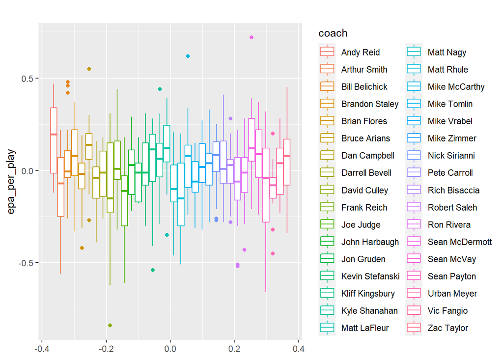

```r
ggplot(team_sum2, aes(x = ,
                     y = epa_per_play,
                     color=coach)) +
  geom_boxplot() +
  labs(title = "")
```

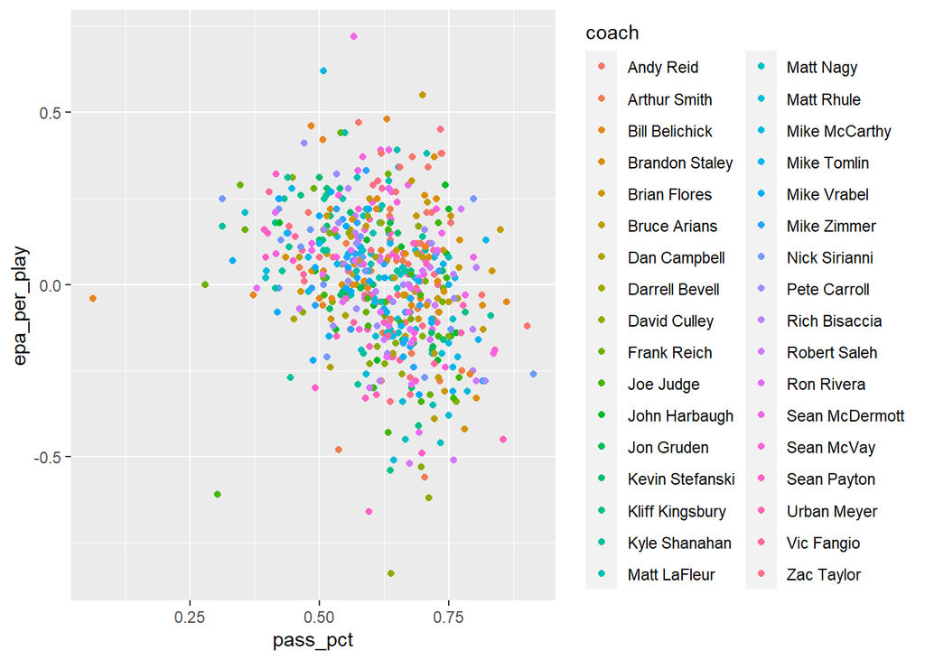

```r
ggplot(team_sum2, aes(x=pass_pct, y=epa_per_play, color=coach)) + geom_point()
```

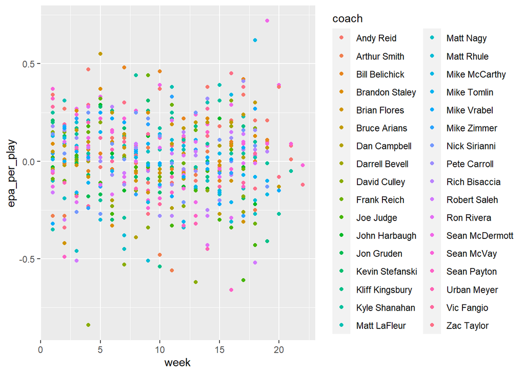

```r
ggplot(team_sum2,aes(x=week, y=epa_per_play, color=coach)) + geom_point()
```

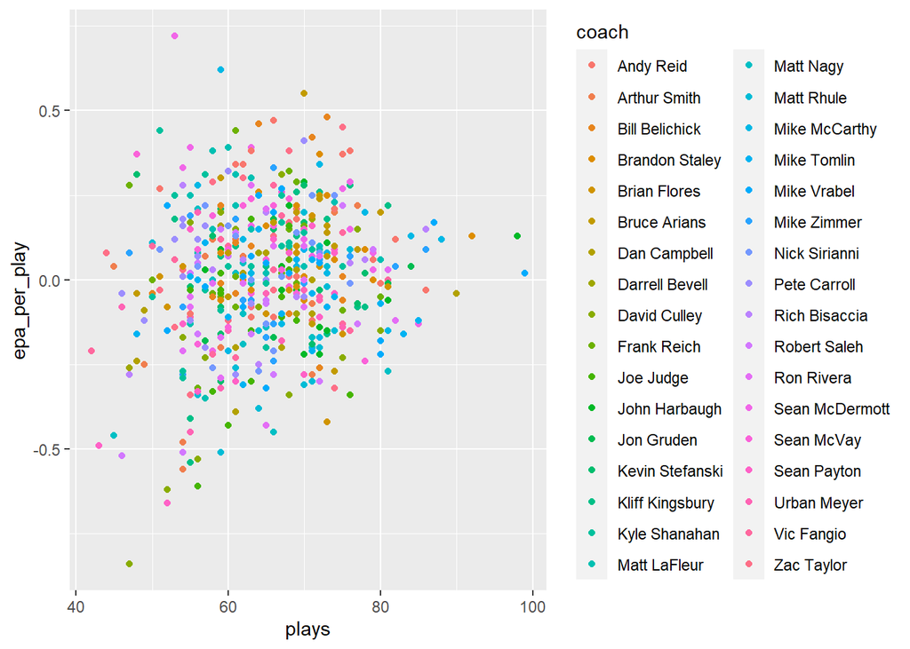

```r
ggplot(team_sum2, aes(x=plays, y=epa_per_play, color=coach)) + geom_point()
```

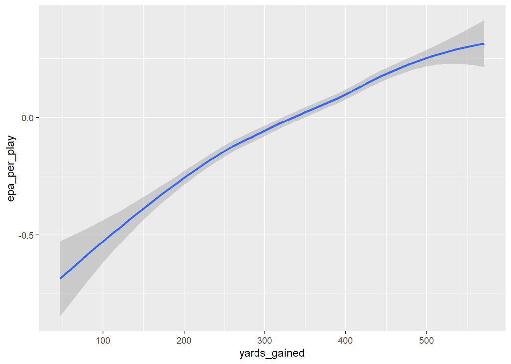

```r
team_sum2 |>
  ggplot(aes(y=epa_per_play, x=yards_gained)) +
  geom_smooth(method = "loess")
```

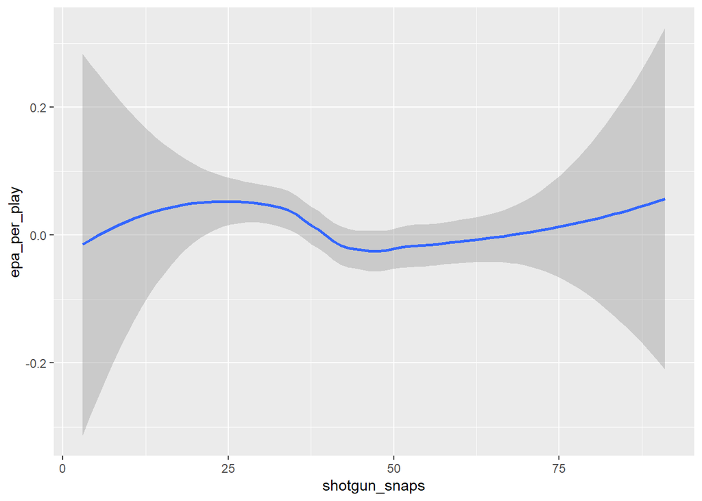

```r
team_sum2 |>
  ggplot(aes(y=epa_per_play, x=shotgun_snaps)) +
  geom_smooth(method = "loess")
```

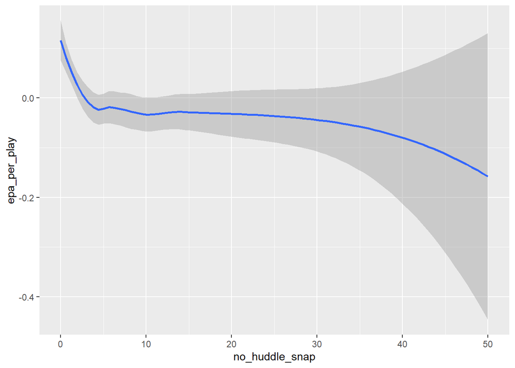

```r
team_sum2 |>
  ggplot(aes(y=epa_per_play, x=no_huddle_snap)) +
  geom_smooth(method = "loess")
```

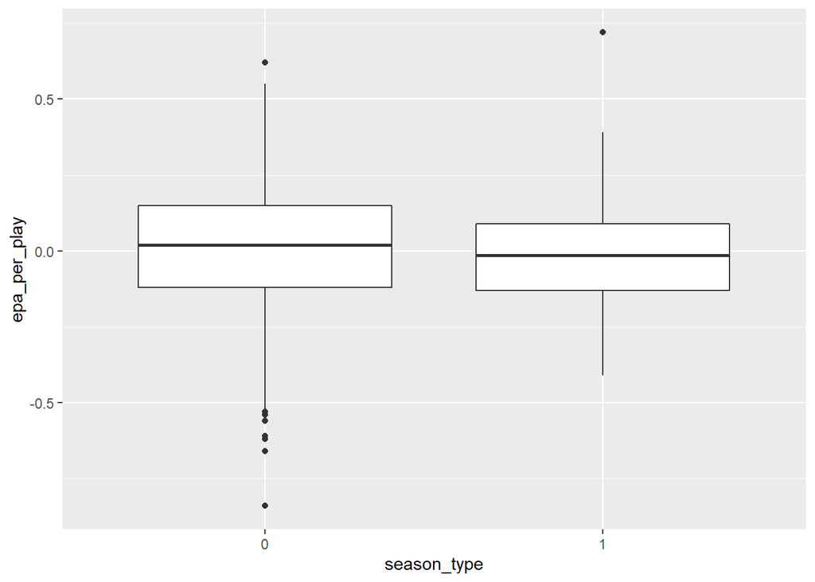

```r
team_sum2$season_type <- as.factor(team_sum2$season_type)
team_sum2$home_adv <- as.factor(team_sum2$home_adv)

ggplot(team_sum2,aes(x=season_type, y=epa_per_play)) + geom_boxplot()
```

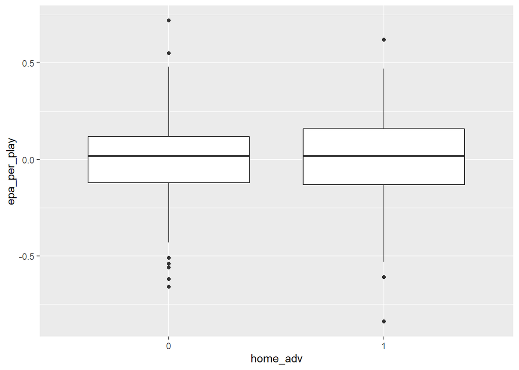

```r
ggplot(team_sum2, aes(home_adv, epa_per_play)) + geom_boxplot()
```

[figure not shown]

```r
offense <- pbp %>%
  dplyr::group_by(team = posteam) %>%
  dplyr::summarise(off_epa = mean(epa, na.rm = TRUE))
defense <- pbp %>%
  dplyr::group_by(team = defteam) %>%
  dplyr::summarise(def_epa = mean(epa, na.rm = TRUE))
offense %>%
  dplyr::inner_join(defense, by = "team") %>%
  ggplot2::ggplot(aes(x = off_epa, y = def_epa)) +
  ggplot2::geom_abline(slope = -1.5, intercept = c(.4, .3, .2, .1, 0, -.1, -.2, -.3), alpha = .2) +
  nflplotR::geom_mean_lines(aes(h_var = off_epa, v_var = def_epa)) +
  nflplotR::geom_nfl_logos(aes(team_abbr = team), width = 0.07, alpha = 0.7) +
  ggplot2::labs(
    x = "Offense EPA/play",
    y = "Defense EPA/play",
    title = "2021 NFL Offensive and Defensive EPA per Play"
  ) +
  ggplot2::theme_bw() +
  ggplot2::theme(
    plot.title = ggplot2::element_text(size = 12, hjust = 0.5, face = "bold")
  ) +
  ggplot2::scale_y_reverse()
```

### Statistical Modeling

#### Linear Model

```r
epa.lm = lm(epa_per_play ~ pass_pct + plays + yards_gained + shotgun_snaps + no_huddle_snap, data=team_sum2)
summary(epa.lm)
```

```
##
## Call:
## lm(formula = epa_per_play ~ pass_pct + plays + yards_gained +
##     shotgun_snaps + no_huddle_snap, data = team_sum2)
##
## Residuals:
##      Min       1Q   Median       3Q      Max
## -0.47720 -0.07899  0.00753  0.08871  0.35041
##
## Coefficients:
##                  Estimate Std. Error t value Pr(>|t|)
## (Intercept)    -6.873e-02  5.403e-02  -1.272    0.204
## pass_pct       -3.627e-01  5.907e-02  -6.139 1.63e-09 ***
## plays          -6.159e-03  8.583e-04  -7.176 2.44e-12 ***
## yards_gained    2.024e-03  7.539e-05  26.842  < 2e-16 ***
## shotgun_snaps   4.161e-04  6.035e-04   0.689    0.491
## no_huddle_snap -2.163e-03  8.125e-04  -2.662    0.008 **
## ---
## Signif. codes:  0 '***' 0.001 '**' 0.01 '*' 0.05 '.' 0.1 ' ' 1
##
## Residual standard error: 0.1254 on 530 degrees of freedom
##   (34 observations deleted due to missingness)
## Multiple R-squared:  0.6302, Adjusted R-squared:  0.6267
## F-statistic: 180.7 on 5 and 530 DF,  p-value: < 2.2e-16
```

- after accounting for the other variables, the number of shotgun snaps an offense runs does not appear to significantly effect epa per play. Current model explains approximately 63% of the variance in epa per play.

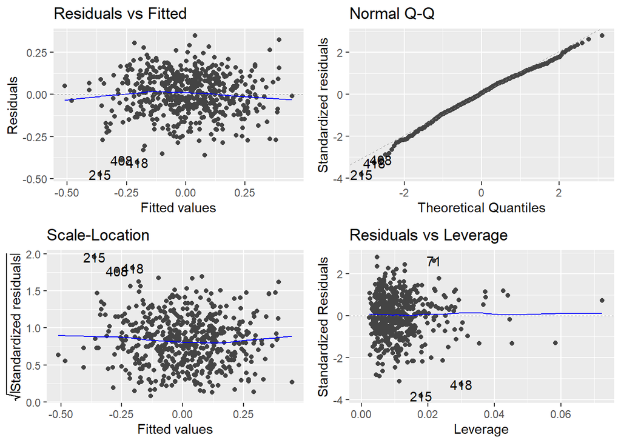

```r
autoplot(epa.lm)
```

- a few outliers are present, but the overall fit looks acceptable

#### Linear Mixed Effects Model

We want to account for a teams coach and if a team has home field advantage as random effects.

```r
epa.lmer1 = lmer(epa_per_play ~ pass_pct + plays + yards_gained + no_huddle_snap +
(1|coach) + (1|home_adv), data=team_sum2)
```

```r
epa.lmer1
```

```
## Linear mixed model fit by REML ['lmerModLmerTest']
## Formula: epa_per_play ~ pass_pct + plays + yards_gained + no_huddle_snap +
##     (1 | coach) + (1 | home_adv)
##    Data: team_sum2
## REML criterion at convergence: -657.5259
## Random effects:
##  Groups   Name        Std.Dev.
##  coach    (Intercept) 0.02138
##  home_adv (Intercept) 0.00000
##  Residual             0.12358
## Number of obs: 536, groups:  coach, 34; home_adv, 2
## Fixed Effects:
##    (Intercept)        pass_pct           plays    yards_gained  no_huddle_snap
##      -0.065738       -0.360035       -0.005792        0.001993       -0.002185
## optimizer (nloptwrap) convergence code: 0 (OK) ; 0 optimizer warnings; 1 lme4 warnings
```

#### Interpreting the Random Effects

- we observe the home advantage random effect approaches zero, concluding there is no additional change in epa per play due to home field advantage itself.
- we observe an additional 0.02 epa per play due to coaching

```r
coef(epa.lmer1)
```

```
## $coach
##                 (Intercept)   pass_pct        plays yards_gained no_huddle_snap
## Andy Reid       -0.04320522 -0.3600351 -0.005791862  0.001992788   -0.002184533
## Arthur Smith    -0.07545211 -0.3600351 -0.005791862  0.001992788   -0.002184533
## Bill Belichick  -0.06125237 -0.3600351 -0.005791862  0.001992788   -0.002184533
## Brandon Staley  -0.05998892 -0.3600351 -0.005791862  0.001992788   -0.002184533
## Brian Flores    -0.04802109 -0.3600351 -0.005791862  0.001992788   -0.002184533
## Bruce Arians    -0.04782538 -0.3600351 -0.005791862  0.001992788   -0.002184533
## Dan Campbell    -0.07769279 -0.3600351 -0.005791862  0.001992788   -0.002184533
## Darrell Bevell  -0.06463750 -0.3600351 -0.005791862  0.001992788   -0.002184533
## David Culley    -0.08170016 -0.3600351 -0.005791862  0.001992788   -0.002184533
## Frank Reich     -0.06182493 -0.3600351 -0.005791862  0.001992788   -0.002184533
## Joe Judge       -0.06773172 -0.3600351 -0.005791862  0.001992788   -0.002184533
## John Harbaugh   -0.07460723 -0.3600351 -0.005791862  0.001992788   -0.002184533
## Jon Gruden      -0.07307754 -0.3600351 -0.005791862  0.001992788   -0.002184533
## Kevin Stefanski -0.06918734 -0.3600351 -0.005791862  0.001992788   -0.002184533
## Kliff Kingsbury -0.05564862 -0.3600351 -0.005791862  0.001992788   -0.002184533
## Kyle Shanahan   -0.08706086 -0.3600351 -0.005791862  0.001992788   -0.002184533
## Matt LaFleur    -0.04161529 -0.3600351 -0.005791862  0.001992788   -0.002184533
## Matt Nagy       -0.07627911 -0.3600351 -0.005791862  0.001992788   -0.002184533
## Matt Rhule      -0.07697774 -0.3600351 -0.005791862  0.001992788   -0.002184533
## Mike McCarthy   -0.06800655 -0.3600351 -0.005791862  0.001992788   -0.002184533
## Mike Tomlin     -0.05067471 -0.3600351 -0.005791862  0.001992788   -0.002184533
## Mike Vrabel     -0.06455181 -0.3600351 -0.005791862  0.001992788   -0.002184533
## Mike Zimmer     -0.07799479 -0.3600351 -0.005791862  0.001992788   -0.002184533
## Nick Sirianni   -0.06563687 -0.3600351 -0.005791862  0.001992788   -0.002184533
## Pete Carroll    -0.05485163 -0.3600351 -0.005791862  0.001992788   -0.002184533
## Rich Bisaccia   -0.07533029 -0.3600351 -0.005791862  0.001992788   -0.002184533
## Robert Saleh    -0.07004850 -0.3600351 -0.005791862  0.001992788   -0.002184533
## Ron Rivera      -0.07123896 -0.3600351 -0.005791862  0.001992788   -0.002184533
## Sean McDermott  -0.04492282 -0.3600351 -0.005791862  0.001992788   -0.002184533
## Sean McVay      -0.06487735 -0.3600351 -0.005791862  0.001992788   -0.002184533
## Sean Payton     -0.08293789 -0.3600351 -0.005791862  0.001992788   -0.002184533
## Urban Meyer     -0.06971178 -0.3600351 -0.005791862  0.001992788   -0.002184533
## Vic Fangio      -0.06030615 -0.3600351 -0.005791862  0.001992788   -0.002184533
## Zac Taylor      -0.07022429 -0.3600351 -0.005791862  0.001992788   -0.002184533
##
## $home_adv
##   (Intercept)   pass_pct        plays yards_gained no_huddle_snap
## 0 -0.06573825 -0.3600351 -0.005791862  0.001992788   -0.002184533
## 1 -0.06573825 -0.3600351 -0.005791862  0.001992788   -0.002184533
##
## attr(,"class")
## [1] "coef.mer"
```

- each coach is assigned a different intercept, but the fixed effects are the same for all coaches. This model is called a Random Intercept model; we are accounting for baseline differences in epa per play. Alternatively, in a Random Slope model, each coach is allowed to have a different intercept, as well as different slopes for the effect of number of plays ran and percentage of pass plays, etc. We implement a Random Slope model below:

```r
epa.lmer2 = lmer(epa_per_play ~ pass_pct + plays + yards_gained + shotgun_snaps + no_huddle_snap +
(1+pass_pct|coach) + (1+plays|coach) + (1+yards_gained|coach) + (1+shotgun_snaps|coach) + (1+no_huddle_snap|coach), data=team_sum2)
```

```r
coef(epa.lmer2)
```

```
## $coach
##                  (Intercept)   pass_pct        plays yards_gained shotgun_snaps
## Andy Reid       -0.021359274 -0.3531267 -0.005920478  0.001993818  1.749017e-04
## Arthur Smith    -0.022083270 -0.4142316 -0.005113794  0.002300685 -4.957154e-04
## Bill Belichick  -0.099322247 -0.3212672 -0.005546947  0.002085079  2.004335e-03
## Brandon Staley  -0.039546122 -0.3676882 -0.005228272  0.001907321  9.061088e-04
## Brian Flores    -0.030890088 -0.3405987 -0.005908078  0.001812615  5.210091e-04
## Bruce Arians    -0.006272674 -0.3471742 -0.005303429  0.002162985 -1.977314e-03
## Dan Campbell    -0.032217747 -0.4129932 -0.005060821  0.002025353  3.994585e-04
## Darrell Bevell  -0.028422450 -0.3835692 -0.004884982  0.002069152  9.519509e-05
## David Culley     0.025594793 -0.4434270 -0.005312991  0.002354607 -8.647910e-04
## Frank Reich     -0.029715701 -0.3836629 -0.005006014  0.001926449  7.251137e-04
## Joe Judge       -0.110765025 -0.3685520 -0.005240164  0.002157964  2.324016e-03
## John Harbaugh   -0.067015421 -0.3765759 -0.005454016  0.001696361 -2.332450e-05
## Jon Gruden      -0.044756630 -0.4076117 -0.006117469  0.001690010 -9.575563e-04
## Kevin Stefanski -0.051138914 -0.3929423 -0.005965580  0.001687864  4.413235e-04
## Kliff Kingsbury  0.004432622 -0.3922584 -0.004794546  0.002125746  2.578478e-03
## Kyle Shanahan   -0.066230687 -0.4199778 -0.004845848  0.001959183 -5.513684e-04
## Matt LaFleur    -0.015488584 -0.3646239 -0.006144116  0.001935466 -2.198091e-03
## Matt Nagy       -0.003132449 -0.4570784 -0.005295651  0.001782228 -4.219150e-04
## Matt Rhule      -0.023174589 -0.4234071 -0.005044287  0.002079820  6.407123e-04
## Mike McCarthy   -0.047131005 -0.3794069 -0.006171401  0.001887744 -7.481445e-04
## Mike Tomlin     -0.030174637 -0.3446559 -0.005622578  0.001666302 -1.538403e-04
## Mike Vrabel     -0.063523901 -0.3722853 -0.005228042  0.001768247  5.924738e-04
## Mike Zimmer     -0.036775444 -0.4093844 -0.005798129  0.001581682  7.077865e-04
## Nick Sirianni   -0.005244444 -0.3851682 -0.006040989  0.001610259 -8.872969e-04
## Pete Carroll    -0.032091132 -0.3597116 -0.005703681  0.001806320 -8.171638e-04
## Rich Bisaccia   -0.055956687 -0.4088826 -0.005026224  0.001938268  1.300331e-03
## Robert Saleh    -0.050269051 -0.3914232 -0.006229075  0.001939186 -4.069591e-04
## Ron Rivera      -0.022584212 -0.4070039 -0.005237310  0.002045050 -1.163854e-04
## Sean McDermott  -0.036039894 -0.3386200 -0.006420426  0.002175378  1.036268e-03
## Sean McVay      -0.061218926 -0.3689228 -0.006372047  0.001842214  5.035472e-05
## Sean Payton      0.008634449 -0.4736645 -0.004648304  0.002269573 -1.405569e-03
## Urban Meyer     -0.060969177 -0.4025926 -0.006040554  0.001659990 -4.572785e-04
## Vic Fangio      -0.042185111 -0.3921890 -0.005941879  0.001852138 -1.434763e-03
## Zac Taylor      -0.008608472 -0.4348386 -0.005735469  0.001877140 -2.800729e-03
##                 no_huddle_snap
## Andy Reid        -5.153587e-03
## Arthur Smith     -5.116493e-03
## Bill Belichick   -4.105297e-03
```

[output cut: 19 more lines]

```
## Mike Zimmer      -2.572787e-03
## Nick Sirianni    -1.725061e-03
## Pete Carroll     -2.467859e-03
## Rich Bisaccia    -3.423562e-03
## Robert Saleh     -1.236904e-03
## Ron Rivera       -2.632732e-03
## Sean McDermott   -5.880602e-03
## Sean McVay       -3.939260e-03
## Sean Payton      -3.208590e-03
## Urban Meyer      -3.335355e-03
## Vic Fangio       -3.842846e-03
## Zac Taylor       -2.823556e-03
##
## attr(,"class")
## [1] "coef.mer"
```

- here the model is expecting different baseline levels of plays ran and pass_pct
- despite the individual variation of pass_pct, all the values are negative and very close to each other. We see consistency with how often coaches throw the ball. The variation in number of shotgun snaps an offense runs is much wider.

#### Testing for significance between models

*with and without home field advantage

```r
epa.lmer2.null = lmer(epa_per_play ~ pass_pct + plays + yards_gained + shotgun_snaps + no_huddle_snap +
                  (1+pass_pct|coach) + (1+plays|coach) + (1+yards_gained|coach) + (1+shotgun_snaps|coach) + (1+no_huddle_snap|coach),                                            data=team_sum2,
                  REML=FALSE)

epa.lmer2.full = lmer(epa_per_play ~ home_adv + pass_pct + plays + yards_gained + shotgun_snaps + no_huddle_snap +
                  (1+home_adv|coach) + (1+pass_pct|coach) + (1+plays|coach) + (1+yards_gained|coach) + (1+shotgun_snaps|coach) + (1+no_huddle_snap|coach),                       data=team_sum2,
                  REML=FALSE)
```

```r
anova(epa.lmer2.full, epa.lmer2.null)
```

```
## Data: team_sum2
## Models:
## epa.lmer2.null: epa_per_play ~ pass_pct + plays + yards_gained + shotgun_snaps + no_huddle_snap + (1 + pass_pct | coach) + (1 + plays | coach) + (1 + yards_gained | coach) + (1 + shotgun_snaps | coach) + (1 + no_huddle_snap | coach)
## epa.lmer2.full: epa_per_play ~ home_adv + pass_pct + plays + yards_gained + shotgun_snaps + no_huddle_snap + (1 + home_adv | coach) + (1 + pass_pct | coach) + (1 + plays | coach) + (1 + yards_gained | coach) + (1 + shotgun_snaps | coach) + (1 + no_huddle_snap | coach)
##                npar     AIC     BIC logLik deviance Chisq Df Pr(>Chisq)
## epa.lmer2.null   22 -660.21 -565.96 352.11  -704.21
## epa.lmer2.full   26 -666.02 -554.63 359.01  -718.02  13.8  4   0.007961 **
## ---
## Signif. codes:  0 '***' 0.001 '**' 0.01 '*' 0.05 '.' 0.1 ' ' 1
```

```r
team_sum2f <- team_sum2 %>% filter(season_type==0) #filtering to regular season only so amount of games per coach is equal
epa.lmer2f = lmer(epa_per_play ~ pass_pct + plays +
(1+pass_pct|coach) + (1+plays|coach), data=team_sum2f)
```

```
## boundary (singular) fit: see help('isSingular')
```

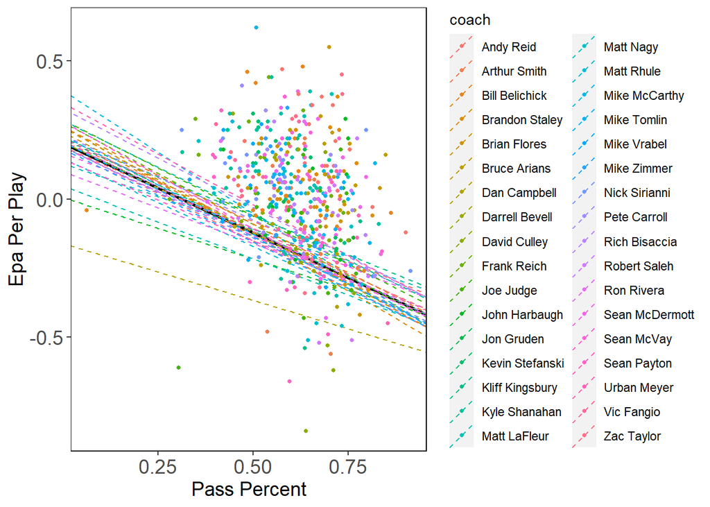

```r
intercepts2 <- rep(coef(epa.lmer2f)$coach[,1], each = 16) #variables needed for plotting
slopes <- rep(coef(epa.lmer2f)$coach[,2], each = 16)
model_intercept <- as.numeric(fixef(epa.lmer2f)[1])
model_slope <- as.numeric(fixef(epa.lmer2f)[2])

ggplot(team_sum2f, aes(x = pass_pct, y = epa_per_play, color=coach)) + #plotting
  geom_abline(slope = model_slope, intercept = model_intercept,
              linetype = "solid", color = "black", size = 1) +
  geom_abline(mapping = aes(slope = slopes,
                            intercept = intercepts2, linetype = coach, color = coach),
              linetype = "dashed", size = .4) +
  geom_point(aes(), size = 1) +
  theme(panel.background = element_blank(),
        panel.grid.major = element_blank(),
        panel.grid.minor = element_blank(),
        panel.border = element_rect(colour = "black", fill = NA),
        legend.position = "right",
        axis.text = element_text(size = 14),
        axis.title = element_text(size = 14)) +
  labs (x = "Pass Percent", y = "Epa Per Play")
```

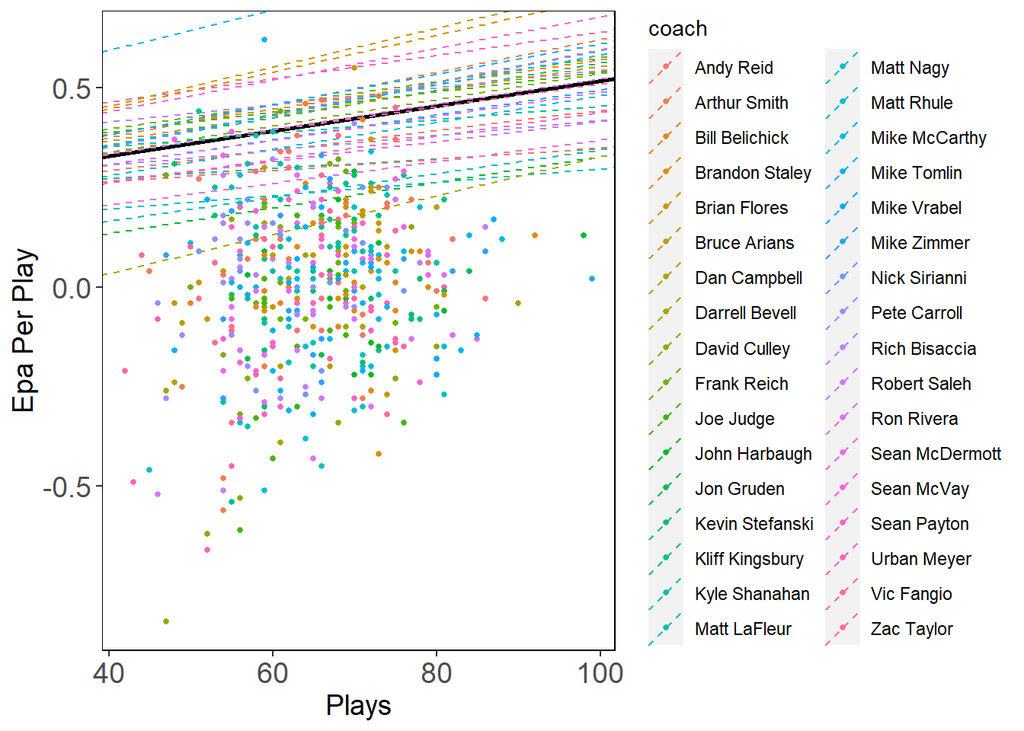

```r
slopes <- rep(coef(epa.lmer2f)$coach[,3], each = 16) #variables needed for plots
model_slope <- as.numeric(fixef(epa.lmer2f)[3])
ggplot(team_sum2f, aes(x = plays, y = epa_per_play, color=coach)) + #plotting
  geom_abline(slope = model_slope, intercept = model_intercept,
              linetype = "solid", color = "black", size = 1) +
  geom_abline(mapping = aes(slope = slopes,
                            intercept = intercepts2, linetype = coach, color = coach),
              linetype = "dashed", size = .4) +
  geom_point(aes(), size = 1) +
  theme(panel.background = element_blank(),
        panel.grid.major = element_blank(),
        panel.grid.minor = element_blank(),
        panel.border = element_rect(colour = "black", fill = NA),
        legend.position = "right",
        axis.text = element_text(size = 14),
        axis.title = element_text(size = 14)) +
  labs (x = "Plays", y = "Epa Per Play")
```

```r
#attempt at visualizing the models  random intercepts plot was too messy

# team_sum2f <- team_sum2 %>% filter(season_type==0)
# epa.lmer1f = lmer(epa_per_play ~ pass_pct + plays +
# (1|coach) + (1|home_adv), data=team_sum2f)
# model_intercept <- as.numeric(fixef(epa.lmer1f)[1])
# model_slope <- as.numeric(fixef(epa.lmer1f)[3])
# intercepts <- rep(coef(epa.lmer1f)$coach[,1], each=16)
#
# ggplot(team_sum2f, aes(x = plays, y = epa_per_play)) +
#   geom_abline(slope = model_slope, intercept = model_intercept,
#               linetype = "solid", color = "black", size = 1) +
#   geom_abline(mapping = aes(slope = model_slope, intercept = intercepts),
#               linetype = "dashed", color = "grey70", size = 1) +
#   geom_point(aes(), size = 1, color = "grey70") +
#   geom_segment(aes(x = plays, xend = plays,
#   y = epa_per_play, yend = fitted(epa.lmer1f)),
#   color = "grey70") +
#   theme(panel.background = element_blank(),
#         panel.grid.major = element_blank(),
#         panel.grid.minor = element_blank(),
#         panel.border = element_rect(colour = "black", fill = NA),
#         legend.position = "none",
#         axis.text = element_text(size = 14),
#         axis.title = element_text(size = 14)) +
#   labs (x = "Play", y = "Epa Per Play")
```

```r
epa.lmer3f = lmer(epa_per_play ~  plays + home_adv + #reducing model to regular season for equal games among coaches
                  (1+home_adv|coach) + (1+plays|coach), data=team_sum2f,
                  REML=FALSE)
```

```
## boundary (singular) fit: see help('isSingular')
```

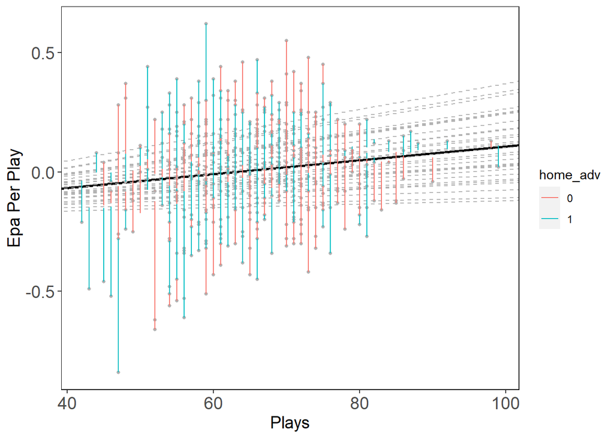

```r
intercepts2 <- rep(coef(epa.lmer3f)$coach[,1], each = 16) #variables for plotting
slopes <- rep(coef(epa.lmer3f)$coach[,2], each = 16)
model_intercept <- as.numeric(fixef(epa.lmer3f)[1])
model_slope <- as.numeric(fixef(epa.lmer3f)[2])

ggplot(team_sum2f, aes(x = plays, y = epa_per_play, color=home_adv)) + #plotting
  geom_abline(slope = model_slope, intercept = model_intercept,
              linetype = "solid", color = "black", size = 1) +
  geom_abline(mapping = aes(slope = slopes,
                            intercept = intercepts2, linetype = coach),
              linetype = "dashed", size = .4, color="grey70") +
  geom_point(aes(color=home_adv), size = 1, color = "grey70") +
  geom_segment(aes(x = plays, xend = plays,
                   y = epa_per_play, yend = fitted(epa.lmer3f)),
               ) +
  theme(panel.background = element_blank(),
        panel.grid.major = element_blank(),
        panel.grid.minor = element_blank(),
        panel.border = element_rect(colour = "black", fill = NA),
        legend.position = "right",
        axis.text = element_text(size = 14),
        axis.title = element_text(size = 14)) +
  labs (x = "Plays", y = "Epa Per Play")
```

## References

Barr, Dale J. 2013. “Random Effects Structure for Testing Interactions in Linear Mixed-Effects Models.” *Frontiers in Psychology*. Frontiers Media SA.

Bates, Douglas, Martin Mächler, Ben Bolker, and Steve Walker. 2014. “Fitting Linear Mixed-Effects Models Using Lme4.” *arXiv Preprint arXiv:1406.5823*.

Bell, Andrew, Malcolm Fairbrother, and Kelvyn Jones. 2019. “Fixed and Random Effects Models: Making an Informed Choice.” *Qual Quant* 53: 1051–74. https://doi.org/10.1007/s11135-018-0802-x.

Brown, Violet A. 2021. “An Introduction to Linear Mixed-Effects Modeling in r.” *Advances in Methods and Practices in Psychological Science* 4 (1): 2515245920960351.

Demidenko, Eugene. 2013. *Mixed Models: Theory and Applications with r*. 2nd ed. Hoboken, New Jersey: John Wiley & Sons, Inc.

Gałecki, Andrzej, and Tomasz Burzykowski. 2013. *Linear Mixed-Effects Models Using r: A Step-by-Step Approach*. New York, NY: Springer Science+Business Media. https://doi.org/10.1007/978-1-4614-3900-4 .

Luger, Tana M, Jerry Suls, and Mark W Vander Weg. 2014. “How Robust Is the Association Between Smoking and Depression in Adults? A Meta-Analysis Using Linear Mixed-Effects Models.” *Addictive Behaviors* 39 (10): 1418–29.

Schielzeth, Holger, Niels J Dingemanse, Shinichi Nakagawa, David F Westneat, Hassen Allegue, Céline Teplitsky, Denis Réale, Ned A Dochtermann, László Zsolt Garamszegi, and Yimen G Araya-Ajoy. 2020. “Robustness of Linear Mixed-Effects Models to Violations of Distributional Assumptions.” *Methods in Ecology and Evolution* 11 (9): 1141–52.